# Homework 5

Scott Sun

## Part 1:

### Q1

- Docker container: an object instance of a Docker image
- Docker image: the template (analogous to class in the context of programming) for creating the realization, Docker container
- Dockerfile: the blueprint to build Docker image

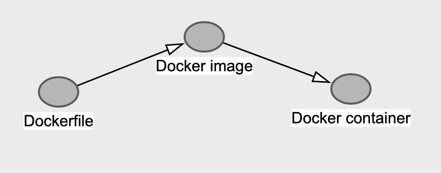

### Q2

`jupyter/pyspark-notebook` has a size of 4.04GB.

### Q3

The following command binds port `8888` in the container to port `823` on the host machine.

```bash
docker run -p 823:8888 jupyter/pyspark-notebook
```

The url used to connect the `JupyterLab` is:  
http://127.0.0.1:823/lab?token=b845fac44c27006664b1919e20d36514c131cce8a85088fc

### Q4

The code return `0.977408`

### Q5

`docker ps` does not return any container in the output table. `docker ps -a` return all the containers. The difference is due to the fact that `docker ps` by default only show containers that are running and `-a` displays all the containers.

### Q6

The file saved before does not exist because by running the image we instantiate a completely new container. The file saved previously is saved in the first container.

### Q7

The `CONTAINER ID` of the original container is `fb67bf8dbae4`, so we run the following command.

```bash
docker start fb67bf8dbae4
```

Then, we use the following command to get the token of the JupyterLab, which is: 3f5232de749dc4fcb90b5241083308c5dbc067edfde492ad

```bash
docker exec fb67bf8dbae4 jupyter server list
```

Finally, we use the url with the updated token to launch JupyterLab and access our original file : http://127.0.0.1:823/lab?token=3f5232de749dc4fcb90b5241083308c5dbc067edfde492ad

### Q8

Assuming the target directory on the local machine is `/usr/jupyter/pyspark`, we copy the files from the container using the following command.

```bash
docker cp fb67bf8dbae4:/home/jovyan/work/hw5_example.ipynb /usr/jupyter/pyspark
```

## Part 2

### (1)

After `cd` to the directory `flask`, use the following commands to build the image and instantiate an container based on the image.

```bash
docker image build -t flask-hw-example .
docker run -p 8000:8000 --name p2-1 flask-hw-example
```

The link to Flask web-app is: localhost:8000

### (2)

After `cd` to the directory `dockerfile2`, use the following commands to build the image and instantiate an container based on the image.

```bash
docker image build -t py-r-hw-example .
docker run --name p2-2 py-r-hw-example
```

## Part 3

### Q9

First, we build the image based on the Dockerfile. After we log into Docker Hub, we need to re-tag the image with the username at the front (i.e., `scotsun/<image-name>`) and finally push as a repo.

```bash
docker image build -t py-r-hw-example .
docker login
docker tag py-r-hw-example:latest scotsun/py-r-hw-example:1.0
docker push scotsun/py-r-hw-example:1.0
```

The link to the image is: https://hub.docker.com/repository/docker/scotsun/py-r-hw-example

### Q10

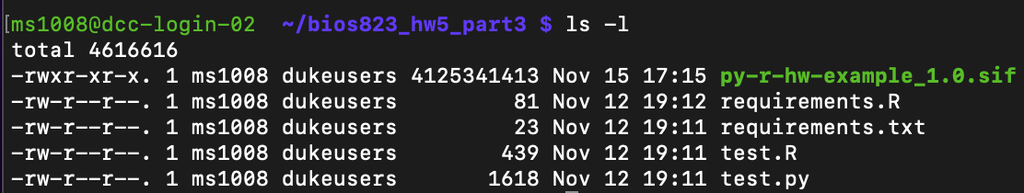

```bash
singularity pull docker://scotsun/py-r-hw-example:1.0
```

The `SIF` container file has a size of 4GB. It has been uploaded to `Sylabs` as a signed repo. Here is the link: https://cloud.sylabs.io/library/scotsun/bios823/py-r-hw-example.sif